# Coursera Reproducible Research Project 2: Analysis of harm and loss caused by natural disasters in the US

## Synopsis:

In this project, both the harm to the population and the economic loss caused by the natural disasters happened in the US during 1950 and November 2011 are analyzed. The loaded database are firstly preprocessed, i.e. filling NAs, mapping new values, then splitted by event types and processed. At the end of this report, the most harmful events on population health, and property/crop damage will be shown.

## Data Processing:

The following chunk of r code loads the data and the necessary library, as well as sets the working directory.

```r
library(plyr)
library(ggplot2)
setwd("/Users/moderato/Desktop/r_wd")
data <- read.csv("repdata-data-StormData.csv")
```

The data should be preprocessed before analyzing. According to the given documentation, the parameters in column PROPDMGEXP and CROPDMGEXP are replaced by corresponding multiplers which are all multiples of 10. Also the names of these two columns are changed, and the NAs are filled with 0.

```r
data$PROPDMGEXP <- revalue(data$PROPDMGEXP, c("-"="0", "?"="0", "+"="1","0"="10","1"="10","2"="10","3"="10","4"="10","5"="10","6"="10","7"="10","8"="10","B"="1000000000","h"="100","H"="100","K"="1000","m"="1000000","M"="1000000"))
data$PROPDMG[data$PROPDMG == ""] <- 0
data$PROPDMGEXP[data$PROPDMGEXP == ""] <- 0
names(data)[26] <- "PROPDMGMUL"

data$CROPDMGEXP <- revalue(data$CROPDMGEXP, c("?"="0", "0"="10","2"="10","B"="1000000000","k"="1000","K"="1000","m"="1000000","M"="1000000"))
data$CROPDMG[data$CROPDMG == ""] <- 0
data$CROPDMGEXP[data$CROPDMGEXP == ""] <- 0
names(data)[28] <- "CROPDMGMUL"
```

Now the database is ready to be used. We split it by event types. Then the harm and loss caused by different events are summed and sorted in a decreasing order. The first six items of each analysis are shown in the following result section.

```r
splittedByEvent <- split(data, data$EVTYPE)
fatalities <- sort(sapply(splittedByEvent, function(x){sum(x[,23], na.rm=TRUE)}), decreasing = TRUE)
injuries <- sort(sapply(splittedByEvent, function(x){sum(x[,24], na.rm=TRUE)}), decreasing = TRUE)
propCropDamage <- sort(sapply(splittedByEvent, function(x){sum(as.numeric(x[,25])*as.numeric(x[,26])+as.numeric(x[,27])*as.numeric(x[,28]), na.rm=TRUE)}), decreasing = TRUE)
```

## Results:

### Fatalities:

```r
head(fatalities)
```

```
##        TORNADO EXCESSIVE HEAT    FLASH FLOOD           HEAT      LIGHTNING
##           5633           1903            978            937            816
##      TSTM WIND
##            504
```

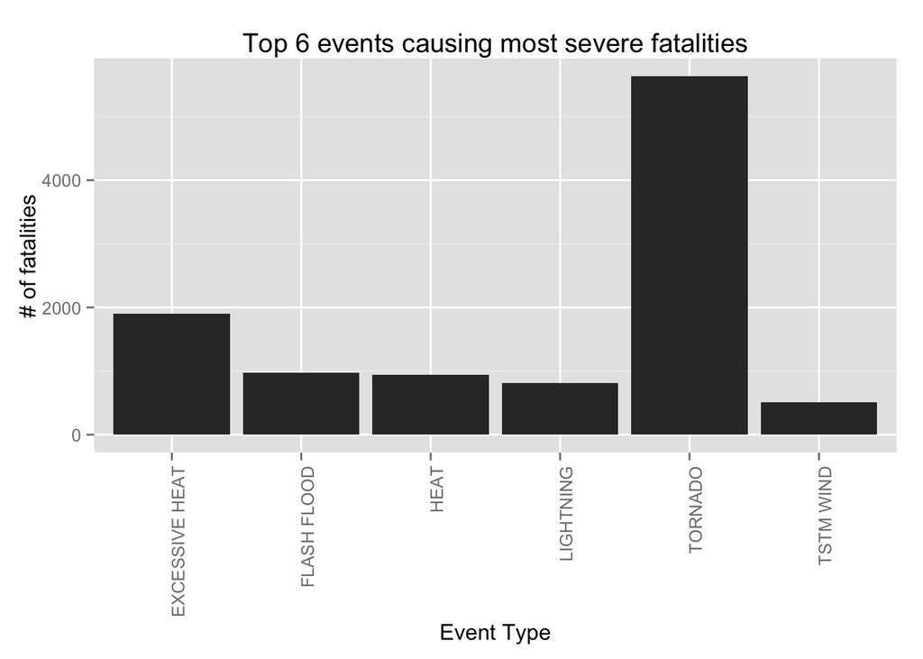

```r
names1 <- names(head(fatalities))
values1 <- head(fatalities)
df1 <- data.frame(names1, values1)
ggplot(data = df1, aes(x = df1$names1, y = df1$values1)) + geom_bar(stat = "identity") + theme(axis.text.x =     element_text(angle = 90, hjust = 1)) + xlab("Event Type") + ylab("# of fatalities") + ggtitle("Top 6 events causing most severe fatalities")
```

### Injuries:

```r
head(injuries)
```

```
##        TORNADO      TSTM WIND          FLOOD EXCESSIVE HEAT      LIGHTNING
##          91346           6957           6789           6525           5230
##           HEAT
##           2100
```

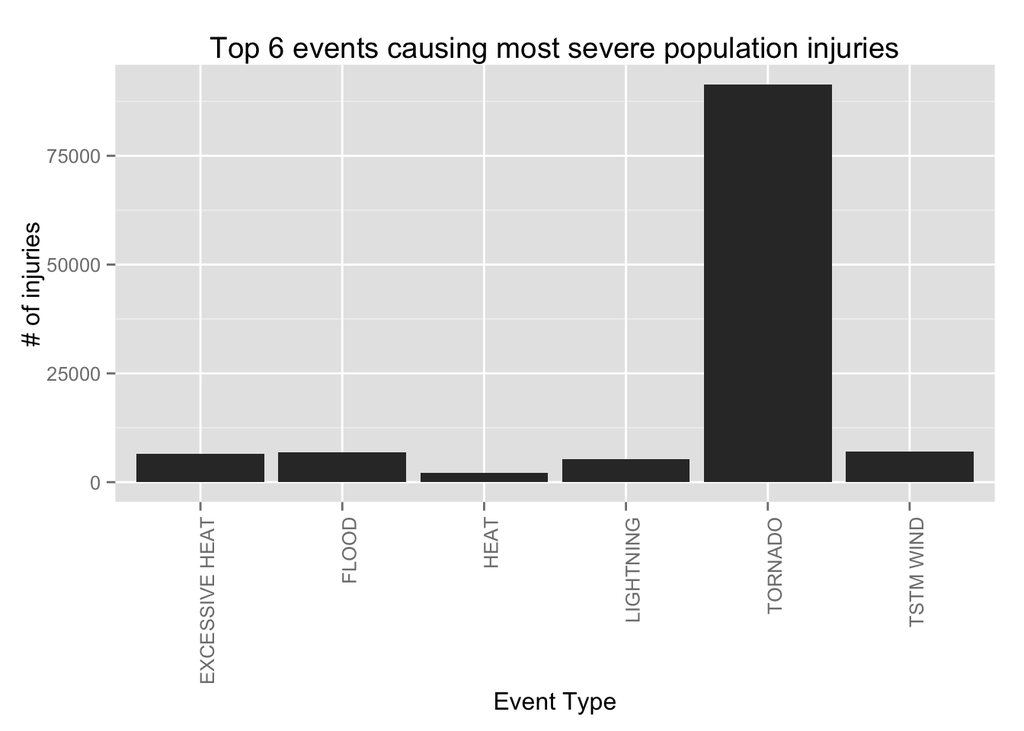

```r
names2 <- names(head(injuries))
values2 <- head(injuries)
df2 <- data.frame(names2, values2)
ggplot(data = df2, aes(x = df2$names2, y = df2$values2)) + geom_bar(stat = "identity") + theme(axis.text.x =     element_text(angle = 90, hjust = 1)) + xlab("Event Type") + ylab("# of injuries") + ggtitle("Top 6 events causing most severe population injuries")
```

### Property and crop damage

```r
head(propCropDamage)
```

```
##           TORNADO       FLASH FLOOD         TSTM WIND              HAIL
##          23033396          10849765           9901205           7733401
##             FLOOD THUNDERSTORM WIND
##           7166257           6474388
```

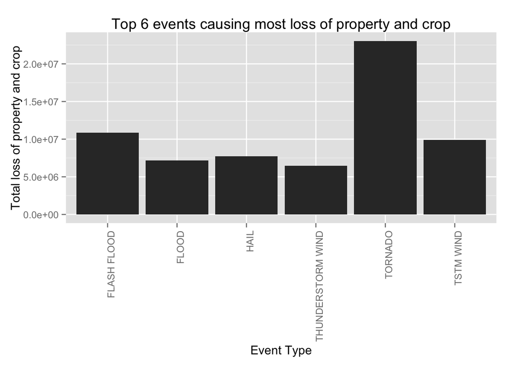

```r
names3 <- names(head(propCropDamage))
values3 <- head(propCropDamage)
df3 <- data.frame(names3, values3)
ggplot(data = df3, aes(x = df3$names3, y = df3$values3)) + geom_bar(stat = "identity") + theme(axis.text.x =     element_text(angle = 90, hjust = 1)) + xlab("Event Type") + ylab("Total loss of property and crop") + ggtitle("Top 6 events causing most loss of property and crop")
```

According to the analysis above, a conclusion can be drawn that tornado is the most dangerous natural disaster in the US during this period.